# iris

## O Danych

Zbiór danych zawiera informacje o trzech gatunkach irysów: Iris setosa, Iris versicolor, i Iris virginica.

Dane obejmują pomiary czterech cech: długość i szerokość działki kielicha oraz długość i szerokość płatka.

Każdy wiersz w zbiorze danych reprezentuje pojedynczy kwiat, a wartości pomiarów są podane w centymetrach.

Zbiór składa się z 150 próbek, po 50 dla każdego gatunku, i jest szeroko stosowany jako podstawowy zbiór danych do testowania algorytmów klasyfikacji oraz w nauce o danych i uczeniu maszynowym.

Kolumny:

- **długość kielicha (sepal length)** - Długość kielicha w cm
- **szerokość kielicha (sepal width)** - Szerokość kielicha w cm
- **długość płatka (petal length)** - Długość płatka w cm
- **szerokość płatka (petal width)** - Szerokość płatka w cm
- **klasa (class)** - Klasa irysa (setosa, versicolor, virginica)

## 1. Ogólny przegląd danych

```python
import pandas as pd
```

```python
df = pd.read_csv('25__iris.csv', sep=",")
df
```

|  | długość kielicha (sepal length) | szerokość kielicha (sepal width) | długość płatka (petal length) | szerokość płatka (petal width) | klasa (class) |
| --- | --- | --- | --- | --- | --- |
| 0 | 5.1 | 3.5 | 1.4 | 0.2 | Iris-setosa |
| 1 | 4.9 | 3.0 | 1.4 | 0.2 | Iris-setosa |
| 2 | 4.7 | 3.2 | 1.3 | 0.2 | Iris-setosa |
| 3 | 4.6 | 3.1 | 1.5 | 0.2 | Iris-setosa |
| 4 | 5.0 | 3.6 | 1.4 | 0.2 | Iris-setosa |
| ... | ... | ... | ... | ... | ... |
| 145 | 6.7 | 3.0 | 5.2 | 2.3 | Iris-virginica |
| 146 | 6.3 | 2.5 | 5.0 | 1.9 | Iris-virginica |
| 147 | 6.5 | 3.0 | 5.2 | 2.0 | Iris-virginica |
| 148 | 6.2 | 3.4 | 5.4 | 2.3 | Iris-virginica |
| 149 | 5.9 | 3.0 | 5.1 | 1.8 | Iris-virginica |

150 rows × 5 columns

Importuję bibloteki które na tą chwilę wydaje mi się że będą potrzebne, będę tu wracał by ewentulanie dodać kolejne importy biblotek.

```python
import seaborn as sns
import matplotlib.pyplot as plt
# Pierwsza linia kodu importuje bibliotekę 'seaborn', którą często skraca się do 'sns'.
#'seaborn' to biblioteka do wizualizacji danych stworzona na bazie 'matplotlib', która oferuje bardziej atrakcyjną wizualnie i zwięzłą składnię.
# Druga linia kodu importuje moduł 'pyplot' z biblioteki 'matplotlib' i nadaje mu alias 'plt'. 'pyplot' to kolekcja funkcji,
# które wprowadzają do 'matplotlib' funkcjonalności podobne do systemów MATPLOTLIB, która jest często używana do tworzenia wykresów w Pythonie.
```

```python
df.info()
# Generuję podstawowe dane o df
# Wiem więc, że mamy 5 kolumn z czego 4 mają warości liczbowe a jedna zawiera tekst.
# Ale podstawowe info jest takie że baza zawiera 150 wartości nie pustych, czyli nie ma warości pustych.
# ! Za pierwszym podejściem generowało mi tylko wartości dla 5 wierszy, nie zauważyłem tego odrazu i nie bardzo wiem z kąd to się wzieło.
# Restart całości dopiero załatwił sprawę.
```

```
<class 'pandas.core.frame.DataFrame'>
RangeIndex: 150 entries, 0 to 149
Data columns (total 5 columns):
 #   Column                            Non-Null Count  Dtype
---  ------                            --------------  -----
 0   długość kielicha (sepal length)   150 non-null    float64
 1   szerokość kielicha (sepal width)  150 non-null    float64
 2   długość płatka (petal length)     150 non-null    float64
 3   szerokość płatka (petal width)    150 non-null    float64
 4   klasa (class)                     150 non-null    object
dtypes: float64(4), object(1)
memory usage: 6.0+ KB
```

- Po odczytaniu "DF", na pierwszy rzut oka widać że na ekranie są widoczne wszystkie kolumny, jednak wierszy jest 150, więc sprawdzę jeszcze 2x losow 5 wierszy.

```python
df.sample(5)
```

|  | długość kielicha (sepal length) | szerokość kielicha (sepal width) | długość płatka (petal length) | szerokość płatka (petal width) | klasa (class) |
| --- | --- | --- | --- | --- | --- |
| 26 | 5.0 | 3.4 | 1.6 | 0.4 | Iris-setosa |
| 88 | 5.6 | 3.0 | 4.1 | 1.3 | Iris-versicolor |
| 131 | 7.9 | 3.8 | 6.4 | 2.0 | Iris-virginica |
| 8 | 4.4 | 2.9 | 1.4 | 0.2 | Iris-setosa |
| 20 | 5.4 | 3.4 | 1.7 | 0.2 | Iris-setosa |

```python
df.sample(5)
# Losowo wybrane wiersze pokazują że baza danych nie posiada brakujących danych,
```

|  | długość kielicha (sepal length) | szerokość kielicha (sepal width) | długość płatka (petal length) | szerokość płatka (petal width) | klasa (class) |
| --- | --- | --- | --- | --- | --- |
| 72 | 6.3 | 2.5 | 4.9 | 1.5 | Iris-versicolor |
| 0 | 5.1 | 3.5 | 1.4 | 0.2 | Iris-setosa |
| 112 | 6.8 | 3.0 | 5.5 | 2.1 | Iris-virginica |
| 46 | 5.1 | 3.8 | 1.6 | 0.2 | Iris-setosa |
| 109 | 7.2 | 3.6 | 6.1 | 2.5 | Iris-virginica |

## 2. Analiza statystyczna

```python
df.describe()
#pokazanie statystyk dla kolumn numerycznych
```

|  | długość kielicha (sepal length) | szerokość kielicha (sepal width) | długość płatka (petal length) | szerokość płatka (petal width) |
| --- | --- | --- | --- | --- |
| count | 150.000000 | 150.000000 | 150.000000 | 150.000000 |
| mean | 5.843333 | 3.054000 | 3.758667 | 1.198667 |
| std | 0.828066 | 0.433594 | 1.764420 | 0.763161 |
| min | 4.300000 | 2.000000 | 1.000000 | 0.100000 |
| 25% | 5.100000 | 2.800000 | 1.600000 | 0.300000 |
| 50% | 5.800000 | 3.000000 | 4.350000 | 1.300000 |
| 75% | 6.400000 | 3.300000 | 5.100000 | 1.800000 |
| max | 7.900000 | 4.400000 | 6.900000 | 2.500000 |

- Średnia długość kielicha: ok. 5.84 cm
- Średnia szerokość kielicha: ok. 3,05 cm
- Średnia długość płatka: ok. 3.76 cm
- Średnia szerokość płatka: ok. 1,2 cm

#### Wniosek: odchylenie standardowe od średniej dla wszystkich pomiarów wskazuje że nie ma zanczących odchyleń wartości minimalnych i maksymalnych.

```python
df.nunique()
# pokazanie wartosci unikatowych w kolumnie
```

```
długość kielicha (sepal length)     35
szerokość kielicha (sepal width)    23
długość płatka (petal length)       43
szerokość płatka (petal width)      22
klasa (class)                        3
dtype: int64
```

- Największa różnorodnośc jest w długości płatka, a najmniejsza w szerokości płatka.

```python
df.isnull().sum()
# Sprawdzam ponownie czy są wartości "puste"
```

```
długość kielicha (sepal length)     0
szerokość kielicha (sepal width)    0
długość płatka (petal length)       0
szerokość płatka (petal width)      0
klasa (class)                       0
dtype: int64
```

- Zbiór nie ma brakujących danych.

```python
print("\nZduplikowane wiersze:", df.duplicated().sum())
```

```
Zduplikowane wiersze: 3
```

```python
duplicates = df[df.duplicated()]

# Do zmiennej 'duplicates' przypisujemy te rekordy z obrabianego dataframe'u 'df', które są zduplikowane.
# W Pythonie możemy to osiągnąć za pomocą metody .duplicated(), która zwraca True dla rekordów, które się powtarzają.

print(f"Liczba zduplikowanych wierszy: {len(duplicates)}")

# Następnie wykorzystujemy funkcję print() do wyświetlenia liczby powtórzonych wierszy. Funkcja len() zwraca liczbę elementów w podanym obiekcie,
# w tym przypadku liczby zduplikowanych rekordów w naszym dataframe. Dzięki użyciu f-stringów, możemy wyświetlić tę wartość bezpośrednio w naszym stringu.
```

```
Liczba zduplikowanych wierszy: 3
```

[output not shown]

- W zduplikowanych kolumnach wartości nie mają większych odchyleń od średniej.
- A ponieważ są to tylko 3 duplikaty i ważą one 2% w całej bazie danych, więc pozostawiam je w df.

# 3. Analiza pojedyńczych zmiennych

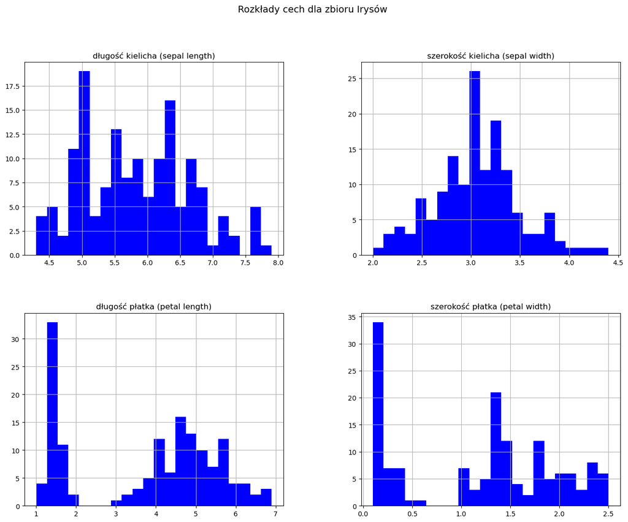

```python
df.hist(figsize=(16,12), bins=22, color='blue')

# Ta linia kodu tworzy wykres histogramu dla każdej kolumny w ramce danych 'df'.
# Dostosowuje rozmiar wykresu do 16x12 (by były one większe i bardziej widoczne), ustawia liczbę przedziałów na 22 i kolor na niebieski.

plt.suptitle("Rozkłady cech dla zbioru Irysów", fontsize=14)

# Za pomocą funkcji 'suptitle' w matplotlib (plt), ustalamy tytuł wykresu na 'Rozkłady cech dla zbioru Irysów' oraz ustawiamy rozmiar czcionki na 14.

plt.show()

# Na koniec, funkcja 'show()' z biblioteki matplotlib jest wywoływana aby wyświetlić wykres.
```

### Wnioski:

- Pomiary długości kielicha są rozproszone, jednak można zaobserwować proporcjonalne rołzożenie wokół średniej wartości,
- Pomiary szerokości kielicha pokazuje prawie podręcznikowy rozkład wokół średniej, występuje wyrażne maksimum i minima,
- Pomiary długości i serokości płatka nie pokazują już tak wyraźnej koncetracji wyników, są rozproszone z lukami w zebranych pomiarach.

# 4. / 5. Transformacja danych i analiza relacji między zmiennymi

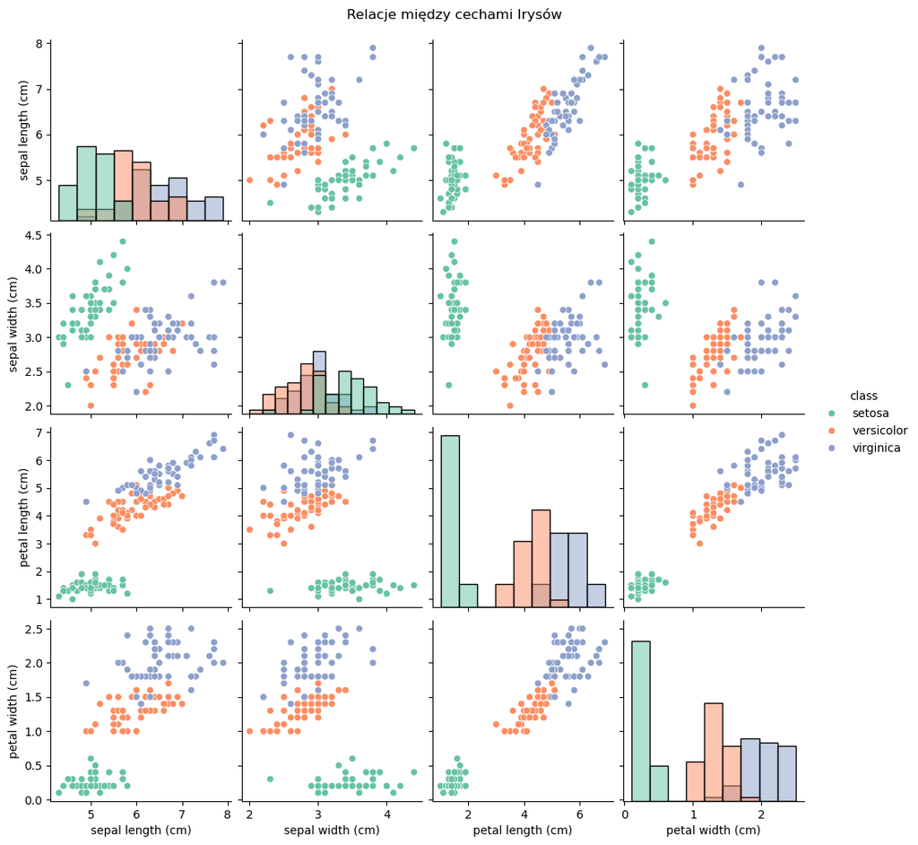

```python
"""
Biblioteka scikit-learn (często importowana jako sklearn) jest fundamentalną biblioteką w ekosystemie Pythona do uczenia maszynowego (Machine Learning).
Główne Funkcje i Zastosowania

scikit-learn to potężne narzędzie, które dostarcza prostych i efektywnych narzędzi do:

    Klasyfikacji (Classification): Przewidywanie, do której kategorii należy dany element (np. czy mail jest spamem, czy zdjęcie przedstawia psa czy kota).

        Przykładowe algorytmy: Lasy losowe (Random Forests), SVM (Support Vector Machines), Regresja logistyczna.

    Regresji (Regression): Przewidywanie wartości ciągłej (np. ceny domu, temperatury, prognozy sprzedaży).

        Przykładowe algorytmy: Regresja liniowa (Linear Regression), Regresja grzbietowa (Ridge), Lasso.

    Klastrowania (Clustering): Grupowaanie podobnych elementów bez wstępnych etykiet (np. segmentacja klientów na podstawie ich zachowań).

        Przykładowe algorytmy: K-Means, DBSCAN.

    Selekcji Modeli (Model Selection): Narzędzia do optymalizacji i walidacji modeli (np. train_test_split do podziału danych, walidacja krzyżowa, wyszukiwanie najlepszych hiperparametrów za pomocą GridSearchCV).

    Preprocessingu Danych (Preprocessing): Transformacja danych, aby były lepiej przygotowane do uczenia maszynowego (np. skalowanie danych za pomocą StandardScaler, kodowanie zmiennych kategorycznych za pomocą OneHotEncoder).

Dlaczego Jest Kluczowa dla Analityka Danych?

    Spójny Interfejs (API): Wszystkie algorytmy w scikit-learn mają ten sam interfejs (metody fit(), predict(), transform()). To sprawia, że zmiana algorytmu na inny jest niezwykle prosta i szybka.

    Integracja: Bezproblemowo współpracuje z Pandas (do wczytywania i manipulacji danymi) oraz NumPy (do obliczeń numerycznych i przechowywania danych).

    Wydajność: W dużej mierze jest zbudowana na NumPY i SciPy, co zapewnia wysoką wydajność obliczeniową.

Podsumowanie Użycia

Gdy pracujesz z biblioteką Pandas nad oczyszczonymi danymi, scikit-learn to kolejny krok, który pozwala Ci:

    Wczytać dane do modelu.

    Przetworzyć je (skalowanie, normalizacja).

    Wytrenować model.

    Ocenić jego wydajność.

    Wykorzystać go do przewidywania nowych danych.
    * z pomocą gemini
"""
# A więc z niej skorzystam

from sklearn.datasets import load_iris
# Pierwsza linijka kodu importuje funkcję load_iris() z biblioteki sklearn.datasets. Ta funkcja jest używana do wczytania zestawu danych zawierającego informacje o irysach.

iris = load_iris()
# Ta linijka kodu wywołuje funkcję load_iris() i przechowuje zwrócone dane w zmiennej iris.
# Zwrócone dane są typem Bunch, co oznacza, że są one podobne do słowników, ale można do nich dostępować za pomocą atrybutów.

df = pd.DataFrame(data=iris.data, columns=iris.feature_names)
# Tutaj tworzymy obiekt DataFrame biblioteki pandas, który jest dwuwymiarowym zestawem danych.
# W założeniu jest to jedna z najważniejszych struktur tej biblioteki.
# Potem zmienna df przechowuje ten obiekt. Do DataFrame przekazujemy iris.data jako dane, a iris.feature_names jako nazwy kolumn.

df['class'] = iris.target
# Dodaje nową kolumnę o nazwie 'class' do DataFrame df i wypełnia ją danymi targetowymi z zestawu danych iris.
# Zestaw danych iris umożliwia klasyfikację irysów do jednej z trzech klas na podstawie różnych cech, stąd nazwa 'class'.

df['class'] = df['class'].map({0: 'setosa', 1: 'versicolor', 2: 'virginica'})
# Ta linijka kodu przekształca liczby 0, 1, 2 w kolumnie 'class' na odpowiednie nazwy gatunków irysów za pomocą metody map().
# Mapowanie to przekształca dane liczbowe na dane kategoryczne.

sns.pairplot(df, hue='class', diag_kind='hist', palette='Set2')
# Funkcja pairplot() z biblioteki seaborn jest używana do tworzenia wykresu relacji par między różnymi cechami w zestawie danych. Hue='class' oznacza,
# że kolor punktów jest określany przez klasę irysów, diag_kind='hist' oznacza, że na przekątnych wykresu znajdują się histogramy cech,
# a palette='Set2' określa schemat kolorów używany do rysowania wykresu.

plt.suptitle("Relacje między cechami Irysów", y=1.02)
# Metoda suptitle() z biblioteki matplotlib jest używana do dodania tytułu do całego wykresu.
# Argument 'Relacje między cechami Irysów' jest tytułem, a y=1.02 ustawia pozycję tytułu.

plt.show()
# Pokazuje wygenerowany wykres. Bez tej linijki kodu, wykres nie zostanie wyświetlony.
```

# Wnioski, na podstawie zebranych próbek:

- Iris Setosa wyraźnie odbiega wymiarami od pozostałych dwóch gatunków Irisów.
- Irysy Versicolor i Virginica w przypadku płatków wykazją częśćiowe nakładanie się pomiarów.
- Występuje wyraźna korelacja między petal length / petal width.
- Korelację można też zaobserwować w : sepal length / petal width oraz petal length / sepal length, co jeszcze bardziej uwidacznia poniższa tablica korelacji.

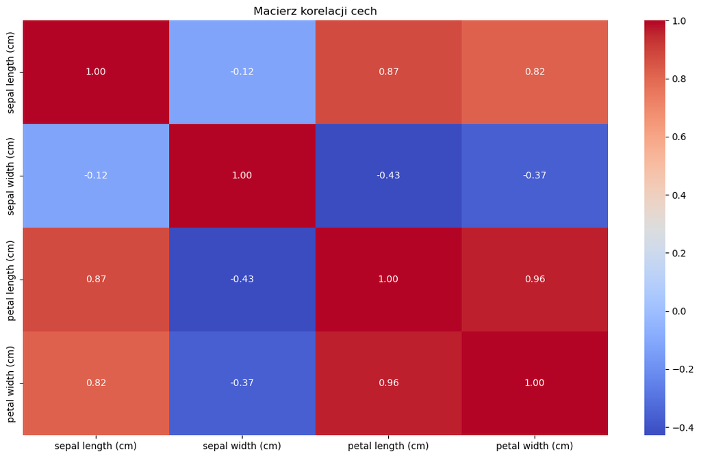

```python
plt.figure(figsize=(14,8))
# Pierwsza linia kodu ustawia rozmiar wykresu na 14x8 cali. Używamy do tego funkcji figure z biblioteki matplotlib.pyplot, której skrótem jest plt.
# W argumencie figsize podajemy wymiary wykresu.

sns.heatmap(df.drop('class', axis=1).corr(), annot=True, cmap='coolwarm', fmt=".2f")
# Następnie używamy funkcji heatmap z biblioteki seaborn, która jest oznaczona jako sns. Ta funkcja tworzy mapę ciepła, która jest wykorzystana do wizualizacji macierzy korelacji.
# Tworzymy macierz korelacji dla DataFrame 'df', ale najpierw z niego usuwamy kolumnę 'class' używając metody drop.
# Argumenty annot i fmt służą do kontrolowania wyglądu etykiet na wykresie - annot=True oznacza, że wartości korelacji będą wyświetlane na wykresie,
# a fmt=".2f" oznacza, że będą one zaokrąglone do dwóch miejsc po przecinku. Argument cmap='coolwarm' określa paletę kolorów używanych na wykresie.

plt.title("Macierz korelacji cech")
# Ta linia kodu ustawia tytuł wykresu na 'Macierz korelacji cech'. Używamy do tego funkcji title z biblioteki matplotlib.pyplot.

plt.show()
# Ostatnia linia kodu wywołuje funkcję show z biblioteki matplotlib.pyplot, która wyświetla utworzony wykres.
```

# 6. Analiza wartości odstających

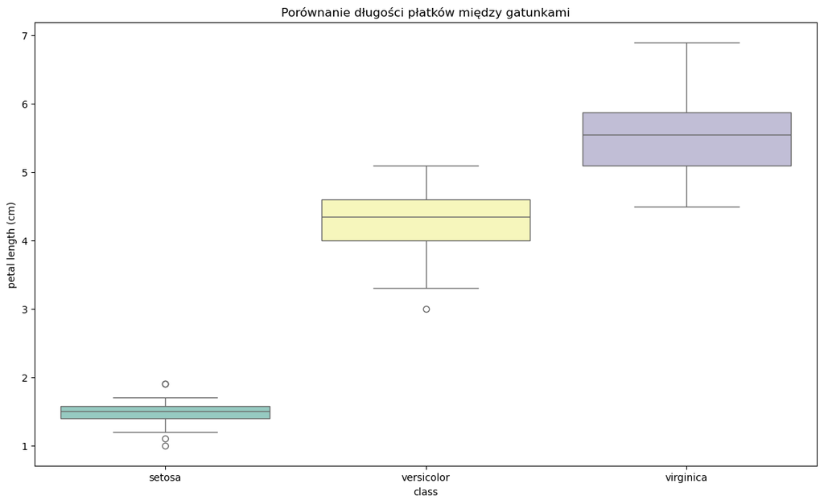

```python
plt.figure(figsize=(14,8))
# Ta linia kodu tworzy nowy wykres za pomocą funkcji 'figure' z biblioteki matplotlib.pyplot, która jest tutaj skrócona do 'plt'.
# Argument 'figsize' określa rozmiar wykresu, tutaj jest to 14 jednostek szerokości i 8 jednostek wysokości.

sns.boxplot(x='class', y='petal length (cm)', hue='class', data=df, palette='Set3', legend=False)
# Ta linia kodu tworzy pudelkowy wykres (boxplot) za pomocą funkcji 'boxplot' z biblioteki seaborn, która jest tutaj skrócona do 'sns'. 'x' to nazwa kolumny w danych,
# która będzie podstawą wykresu (w tym przypadku, jest to 'class'), 'y' to nazwa kolumny, której dane będą przedstawione na wykresie (tutaj, 'petal length (cm)').
# 'hue='class'' oznacza, że różne klasy będą miały różne kolory na wykresie.
# 'data' to ramka danych (DataFrame), z której będą pobierane dane (tutaj 'df'). 'palette' to paleta kolorów, która ma być użyta do wykresu, tutaj określona jako 'Set3'.
# 'legend=False' oznacza, że na wykresie nie będzie legendy.

plt.title("Porównanie długości płatków między gatunkami")
# Ta linia kodu dodaje tytuł do wykresu - 'Porównanie długości płatków między gatunkami', używając funkcji 'title' z matplotlib.pyplot.

plt.show()
# no i na koniec wywołuję funkcję show pokazującą wykres boxplot
```

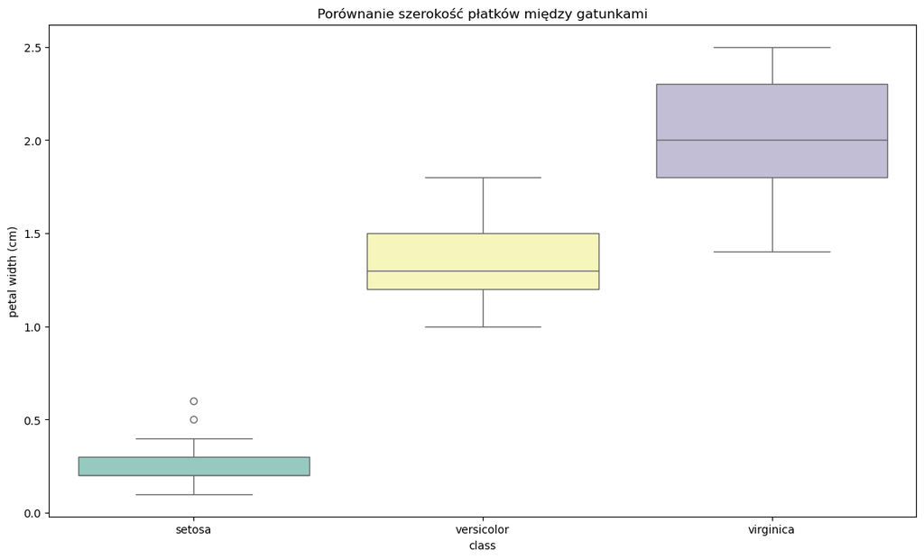

```python
plt.figure(figsize=(14,8))

sns.boxplot(x='class', y='petal width (cm)', hue='class', data=df, palette='Set3', legend=False)

plt.title("Porównanie szerokość płatków między gatunkami")

plt.show()
```

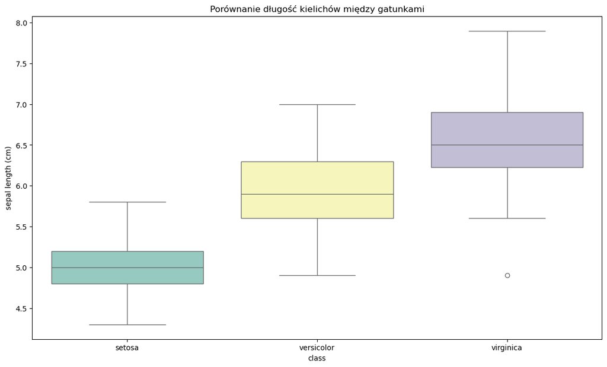

```python
plt.figure(figsize=(14,8))

sns.boxplot(x='class', y='sepal length (cm)', hue='class', data=df, palette='Set3', legend=False)

plt.title("Porównanie długość kielichów między gatunkami")

plt.show()
```

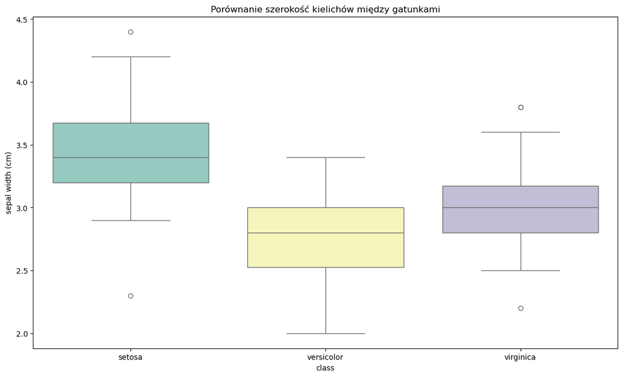

```python
plt.figure(figsize=(14,8))

sns.boxplot(x='class', y='sepal width (cm)', hue='class', data=df, palette='Set3', legend=False)

plt.title("Porównanie szerokość kielichów między gatunkami")

plt.show()
```

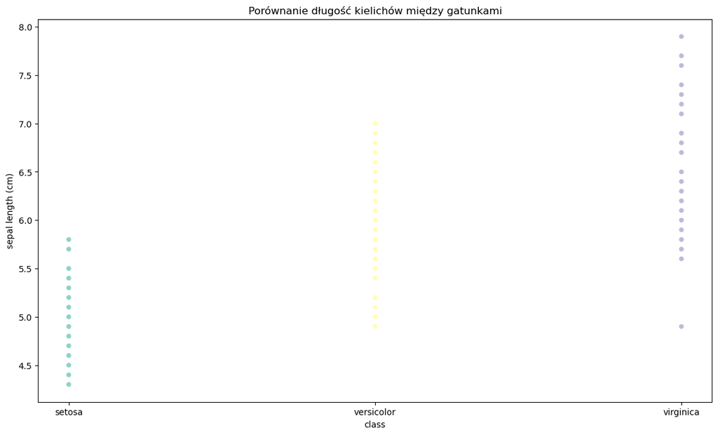

```python
# Zmiana wykresu z boxplot na scatterplot w celu sprawdzenia który wykres jest czytelniejszy
plt.figure(figsize=(14,8))

sns.scatterplot(x='class', y='sepal length (cm)', hue='class', data=df, palette='Set3', legend=False)

plt.title("Porównanie długość kielichów między gatunkami")

plt.show()
```

## Wnioski z analizy wykresów boxplot

- Iris Setosa ma najdrobniejsze płatki zarówno pod względem szerokości jak i długości.
- Iris Versicolor ma płatki od 3-4 razy większy od Setosa, ale ustępuje rozmiarami Irisowi Virginica. Około 25% pobranych próbek obu tych gatunków wykazywało podobne rozmiary.
- W przypadków długości kielichów ponownie najdrobniejszym irysem jest Setosa, jednak dysproporcja w pomiarach nie jest już tak duża, po środku jest Versicolor, a Virginica jest największa.
- Przy pomiarze szerokości kielichów różnice są najmniejsze, Setosa jest pierwsza, Virginica druga, Versicolor trzeci.
- Należy dodać, że w pomiarach wystąpiło bardzo mało wartości odstających, co może świadczyć o dużym doświadczeniu botanika zbierającego pomiary.

# Podsumowanie

- Zbiór pomiarów trzech gatunków Irisów jest kompletny, bez luk i znaczących pomiarów odstających, co świadczy moim zdaniem o dużym doświadczeniu i systematyczności botanika zbierającego próbki.
- Na podstawie zebranych danych można stwierdzić że rozmiar płatków jest wystarczającym kryterium do rozróżnienia badanych gatunków irysów. Natomiast szerokość kielicha się do tego nie nadaje.
- Gatunek Irisa Setosa charakteryzuje się odmienną budową a co za tym idzie najłatwiej go rozróżnić. Pozostałe dwa gatunki wymagają od laika więcej uwagi by ich nie pomylić.